# Estimate viable body temperatures for a given ambient water temperature

Andrew L Jackson

## Setup

```r
# library(predictFishRMR)

library(tidyverse)
```

```r
r_files <- list.files("../r", pattern = ".R", full.names = T)
for (i in 1:length(r_files)){source(r_files[i])}
omega <- 10^5.954


# required for access to the Lambert function
library(lamW)

# for plotting and tibble manipulation
library(tidyverse)

# for multi panel figures
library(patchwork)
```

## Introduction

Here we introduce a model that estimates the body muscle temperature of a fish that balances their heat budget in water of a specified temperature. This model relies on empirical relationships to predict routine metabolic rate (RMR) from body temperature alongside empirically derived estimates of the heat transfer coefficient to predict the equilibria states of a dynamic heat budget model. Specifically the dynamic model we fit is the standard dynamic heat balance model which relates muscle temperature ($T_m$) as a proxy for body temperature to ambient water temperature $T_a$ with parameters $k$ the heat transfer coefficient of the whole body and $\dot{T}_0$ the heat production rate according to metabolism.

$$\frac{dT_m}{dt} = k(T_a(t) - T_m(t)) +
\dot{T}_0$$
which at equilibrium is

$$T_m = T_a + \frac{\dot{T}_0}{k}$$
The goal in what follows is to estimate $\dot{T}_0$ and $k$ using empirically derived relationships with body mass, such that predictions can be made for fish of different body mass with different physiologies (ectothermy and mesothermy / regional endothermy) about what their metabolic rates would be in water of different temperature assuming they balance their energy budgets. The challenge is that the equation immediately above hides the fact that $\dot{T}_0 = f(T_m)$ and results in a somewhat complicated solution.

## Define mathematical functions

The following function is based on the regression of $\log_{10}(RMR)$ against $\log_{10}(mass)$ with slope $\alpha$, body temperature with slope $B$, the additive effect of endothermy $\phi$ and the intercept $\gamma$.This equation is used to esimated $\dot{T}_0$.

Note that ideally I think we would parameterise this in natural logs rather than base 10, which would simplify somewhat the subsequent equations.

Just for noting, the following three equations are equivalent.

$$\log_{10}(RMR) = \alpha\log_{10}(m) +
\beta T_m + \gamma + \phi$$

$$RMR = 10^{(\alpha\log_{10}(m) + \beta
T_m + \gamma + \phi)}$$
$$RMR =
m^\alpha10^{\beta T_m}10^{\gamma}10^{\phi}$$

The difference in temperature between the fish ($T_m$ for body) and the ambient water ($T_a$ for ambient) is then given by

$$T_m - T_a =
\frac{\dot{T}_0}{k}$$

The goal is to estimate the body temperature of a fish $T_m$ in a body of water at a given temperature such that it balances its heat budget. But the difficulty is that $T0$ is itself a function of $T_m$. So we take two approaches. First we take an empirical approach and instead solve for $A$ given a range of body temperatures and invert the axes to yield the relationship between body temperature and ambient water temperature. Second we make use of the Product Log function (Lambert function) to estimate directly the solution in terms of B.

The predicted water temperature as function of body mass is then given as body temperature minus the temperature difference $\Delta T$ which is given by $RMR/k$ where $k$ is the rate of heat loss.

The symobolic solver available at [wolfram](https://www.wolframalpha.com/input?i2d=true&i=solve+for+B%5C%2844%29+A+%3D+B+-+%5C%2840%29Divide%5BPower%5B10%2C%5C%2840%29α*Log10%5Bm%5D%2Bβ*B%2Bγ%2Bω%5C%2841%29%5D%2Cm*Power%5B10%2Cψ%5D*k%5D%5C%2841%29++) yields the following solution where we introduce $B = T_m$ and $A = T_a$ for clarity for the solver.

Natural log form

`solve for B, A = B - (Divide[Exp[α*Ln[m]+β*B+γ],m*ω*k])`

$$T_m = T_a - W_n \left (-\frac{e^{(\beta
T_a + \gamma(S))}(m^{\alpha - 1})\beta}{\omega k}\right) \frac{1}{\beta}$$

## Define parameters and functions for this model

Define the parameters of the model taken from the PGLS regression model.

```r
# order of the parameters is:
# 1 = alpha the coefficient of log10(mass)
# 2 = beta the coefficient of Body temperature
# 3 = Intercept (gamma)
# 4 = the effect of mesothermy (psi)
# 5 = omega, the coefficient of mass for converting RMR to T0
# pars <- c(0.8161589, 0.0505157, 0.8700325, 0.8358592, 10^5.945)
# pars <- c(0.8700325, 0.8161589, 0.0505157 , 0.8358592, 10^5.945)
pars <- c(2.9468, 0.8271, 0.0805, 1.2333)
```

## Test some values

We can start by generating a plot of Tb given Ta and use that as illustrative of the shape of the expected curve.

First we define the size of the fish.

```r
# mass
m = 300
```

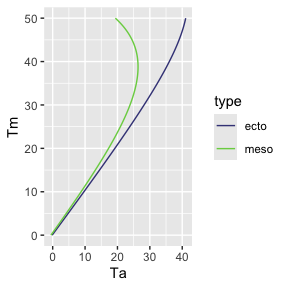

```r
# generate a sequence of plausible body temperature values Tm
Tm_range = seq(0, 50, 0.25)

## A meso - expected Ta and RMR
Ta_est_meso   = Tafun(m, Tm_range, meso = TRUE, pars = pars)
RMR_meso      = RMRfun(m, Tm_range, meso = TRUE, pars = pars) # not used


## An ecto- expected Ta and RMR
Ta_est_ecto   = Tafun(m, Tm_range, meso = FALSE, pars = pars)
RMR_ecto      = RMRfun(m, Tm_range, meso = FALSE, pars = pars) # not used

# Create the data.frame object
dd_meso = data.frame(Tm = Tm_range, Ta = Ta_est_meso)
dd_ecto = data.frame(Tm = Tm_range, Ta = Ta_est_ecto)
dd <- bind_rows(meso = dd_meso, ecto = dd_ecto, .id = "type")

# plot the curve
gg1 <- ggplot(data = dd, mapping = aes(x = Ta, y = Tm, color = type)) +
  geom_path() +
  scale_color_viridis_d(option = "D", begin = 0.2, end = 0.8)

print(gg1)
```

**Figure X.** The relationship between $T_m$ and $T_a$ as derived by evaluating the inverse relationship.

```r
# create a reasonable ambient water temperature range to evaluate our solution on
new_Ta_meso <- seq(-5, maxAmbientTemp(m, meso = TRUE, pars) - 0.000001, length.out = 300)
new_Ta_ecto <- seq(-5, maxAmbientTemp(m, meso = FALSE, pars) - 0.000001, length.out = 300)

# calculate the body temperature solutions for our range of water temperatures
gen_Tb_meso <- bodyTempLambert(new_Ta_meso, m, meso = TRUE, pars = pars)
gen_Tb_ecto <- bodyTempLambert(new_Ta_ecto, m, meso = FALSE, pars = pars)

# create a dataframe that includes Ta for plotting
lam_dd <- bind_rows(meso = gen_Tb_meso,
                    ecto = gen_Tb_ecto,
                    .id = "type") %>%
  rename(Ta = x, Tb = y)
```

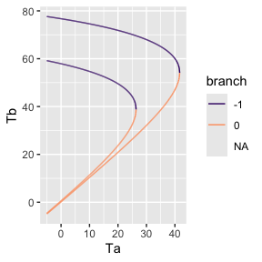

```r
# Plot both arms of the Lambert function
gg_lam <- ggplot(data = lam_dd %>% mutate(branch = as.factor(branch)),
                 mapping = aes(x = Ta, y = Tb,
                               group = type)) +
  geom_path(mapping = aes(color = branch)) +
  scale_color_viridis_d(option = "A", begin = 0.2, end = 0.8)

print(gg_lam)
```

**Figure X.** The predicted $T_m$ as a function of $T_a$ for a 300 Kg mesotherm (left hand curve) and ectotherm (right hand curve) with both branches arising from the Lambert function indicated by colour. Note that the NA factor for “branch” is an artifact of introducing a NA value between the two vectors of the branches so as to not join the the two curves.

Here we plot them side by side and adjust axes limits manually to make them comparable.

[figure not shown]

```r
(gg1 + ylim(-5, 50) + xlim(-10, 50)| gg_lam + ylim(-5, 50) + xlim(-10, 50))
```

**Figure X.** A sanity check that plotting $T_a = f(T_m)$ (left panel) and the preferred direct method $T_m = g(T_a)$ yield (near, since there is some approximation in the direct method) identical solutions.

## Plot max values of Ta by body mass and meso/ecto

The inflection point of the curve occurs in the Lambert function $W_n(x)$ when $x = -\frac{1}{e}$. We use this to derive the value of $Ta$ that satisfies this:

x_max <- (0.43429 * (log((0.43429 * kk * m^(1 - aa)) / (bb)) - (2.3026 * (gg + pp -om)) - 1 )) / bb

x_max <- (-gg + log(kk*om*m^(1-aa) / bb) - 1) / bb

$$T_a^* = \frac{0.43429(\log(\frac{0.43429
k m^{1-\alpha}}{\beta}) - (2.3026 * (\gamma + \psi - \omega)) -
1)}{\beta}$$

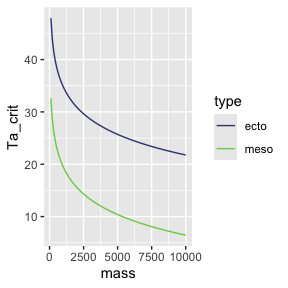

```r
m_range <- seq(100, 10000, length.out = 100)

Ta_crit_meso <- maxAmbientTemp(m_range, meso = TRUE, pars)
Ta_crit_ecto <- maxAmbientTemp(m_range, meso = FALSE, pars)

dd_crit <- data.frame(mass = c(m_range, m_range),
                      Ta_crit = c(Ta_crit_meso, Ta_crit_ecto),
                      type = c(rep("meso", length(m_range)),
                               rep("ecto", length(m_range))))

gg_crit <- ggplot(data = dd_crit,
                  mapping = aes(x = mass, y = Ta_crit,
                                color = type)) +
  geom_path() +
  scale_color_viridis_d(option = "D", begin = 0.2, end = 0.8)

print(gg_crit)
```

**Figure X.** The predicted maximum water temperature in which a fish can maintain heat balance as a function of body mass and physiological type. Note that these are analytical approximations.